# VOCAL Data Exploration

## 1 Descriptives

In this study, participants were asked to list (in free-text format) vocalisations they make in daily life. They could list up to 20 vocalisations.

We have **2336** vocalisations from a total of **279** participants. We randomly selected 3 of the (up to) 20 vocalisations for participants to provide contextual info on. This gave us **693** vocalisations with follow-up context data.

**Participant n per country**

| country_main | n |
| --- | --- |
| United Kingdom of Great Britain and Northern Ireland | 66 |
| Netherlands | 60 |
| Brazil | 51 |
| Hong Kong (S.A.R.) | 16 |
| Germany | 15 |
| United States of America | 15 |
| Bulgaria | 6 |
| Italy | 6 |
| Estonia | 3 |
| India | 3 |
| Lithuania | 3 |
| Australia | 2 |
| Finland | 2 |
| Ireland | 2 |
| Japan | 2 |
| Luxembourg | 2 |
| Russian Federation | 2 |
| Singapore | 2 |
| Spain | 2 |
| Turkey | 2 |
| Belgium | 1 |
| Canada | 1 |
| China | 1 |
| Cyprus | 1 |
| Czech Republic | 1 |
| Denmark | 1 |
| Hungary | 1 |
| Jordan | 1 |
| Poland | 1 |
| Romania | 1 |
| Slovakia | 1 |
| South Africa | 1 |
| Switzerland | 1 |
| Syrian Arab Republic | 1 |
| Taiwan | 1 |
| Viet Nam | 1 |
| Zimbabwe | 1 |

**Vocalisation categories**

| category | n |
| --- | --- |
| Interjections | 121 |
| Laughter | 74 |
| Tutting/Clicking | 54 |
| Sigh | 41 |
| Grunt/groan | 37 |
| Kissing/smacking lips | 27 |
| Hum (multisyllabic) | 26 |
| Hum (hmm sounds) | 22 |
| uhh/umm | 21 |
| Cry/sob | 19 |
| A sounds | 18 |
| Gasp | 17 |
| Bodily functions | 16 |
| Cheering | 15 |
| Screams | 15 |
| Whistle | 15 |
| Growl | 14 |
| Hum (mm sounds) | 14 |
| O sounds | 14 |
| Fricatives (pff) | 13 |
| Yawn | 13 |
| Fricatives (sss/hissing) | 11 |
| Hum (nonverbal) | 11 |
| Fricatives (shushing) | 8 |
| Animal imitations | 7 |
| Clearing throat | 7 |
| Fricatives (off/aff) | 7 |
| Breathing (sniffing/inhale) | 5 |
| Breathing (unspecified) | 5 |
| Moan | 5 |
| Breathing (Snort) | 3 |
| Brr sounds | 3 |
| Fricatives (psiu/psii/psst) | 3 |
| Teeth grinding | 3 |
| Breathing (Panting) | 2 |
| Breathing (exhale) | 2 |
| Roar | 2 |
| Blowing Raspberries | 1 |
| Scoffing | 1 |
| Whimpering/Whining | 1 |

## 2 Vocalisations and Emotions

### 2.1 Vocalisation categories were associated with distinct emotions.

The Master’s students and I coded the free-text responses into categories. Below, you can explore the **top categories** in the data (with more than 10 reported instances), and the **co-occurring emotions**.

**Crying/Sobbing**

e.g., “crying”, “cry”, “weeping”

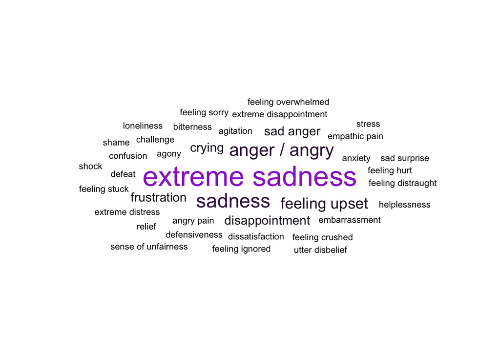

**Screams**

e.g., “scream”, “squeal”, “yelp”, “eeeeek”, “aaaah!! (loud, high pitched)”

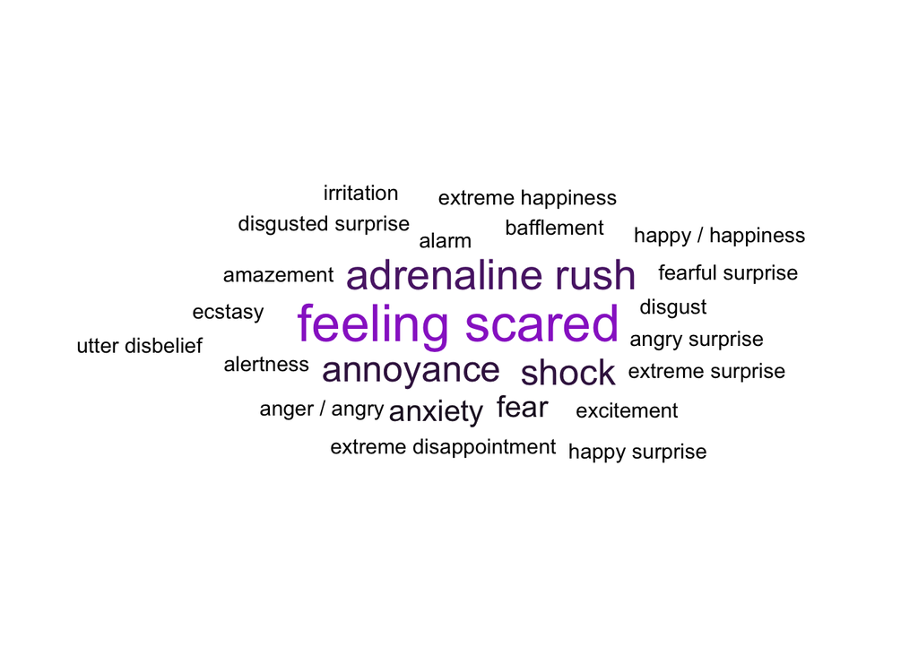

**Bodily functions**

e.g., “coughing”, “sneezing”, “burp”, “snore”

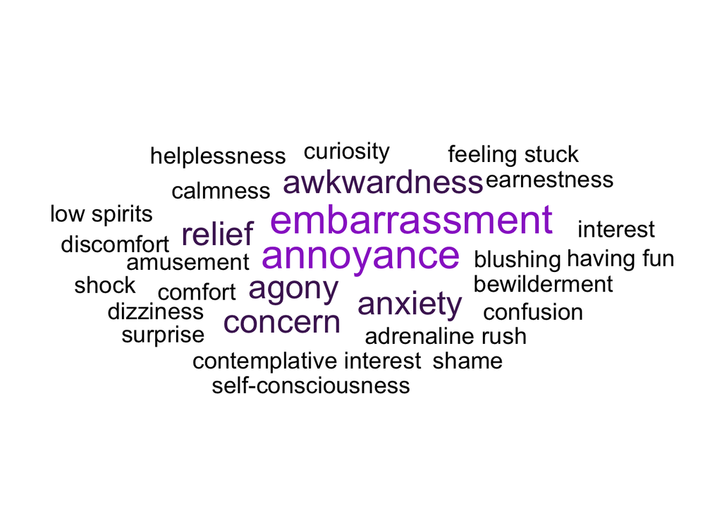

**“Aa” sounds**

“Aa”-based sounds that did not obviously fit other categories like “screaming” or “expressive interjections”

e.g., “aah”, “aah?”, “ah!”

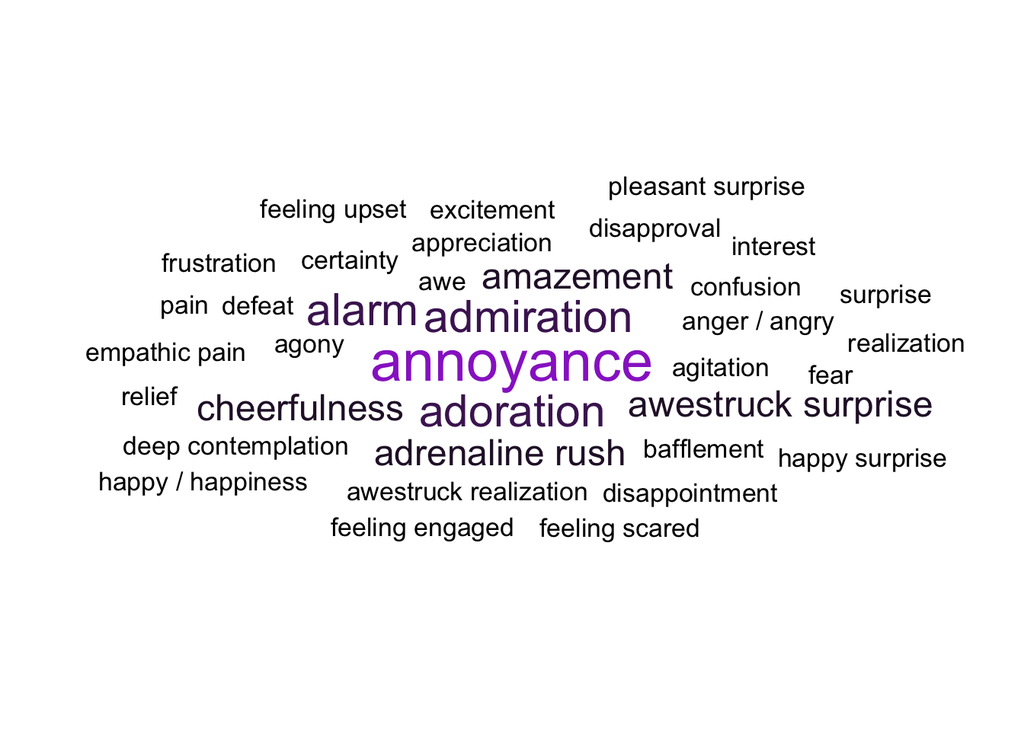

**Grunting/groaning**

e.g., “ugh”, “groaning”, “argh”

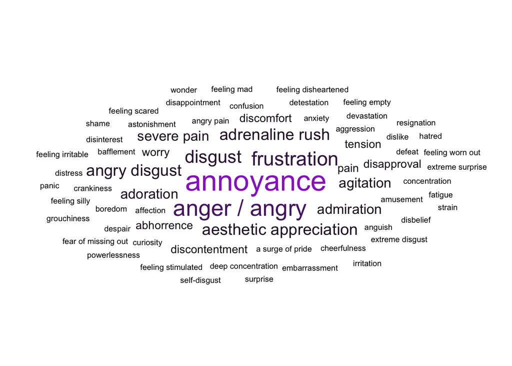

**Yawns**

e.g., “yawning”, “aaaaah yawn”

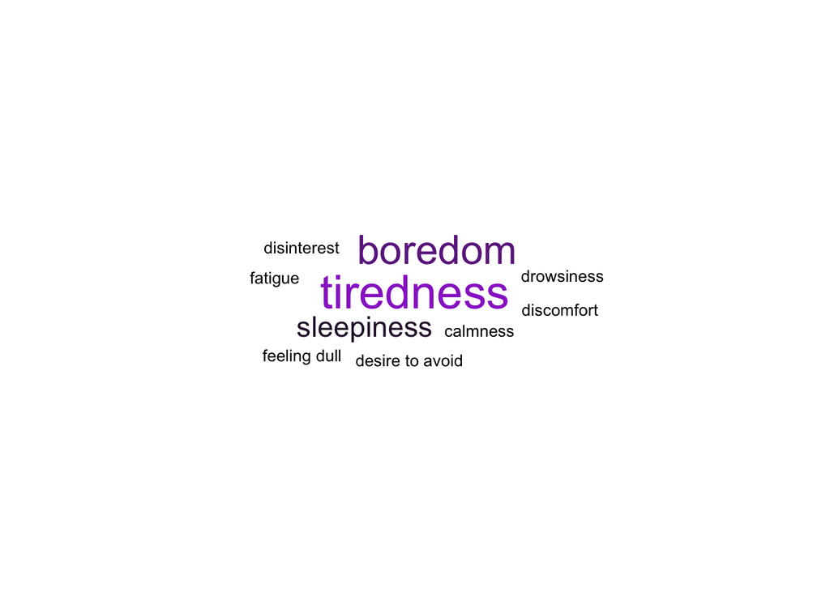

**Gasps**

e.g., “gasping”, “sharp inhale”

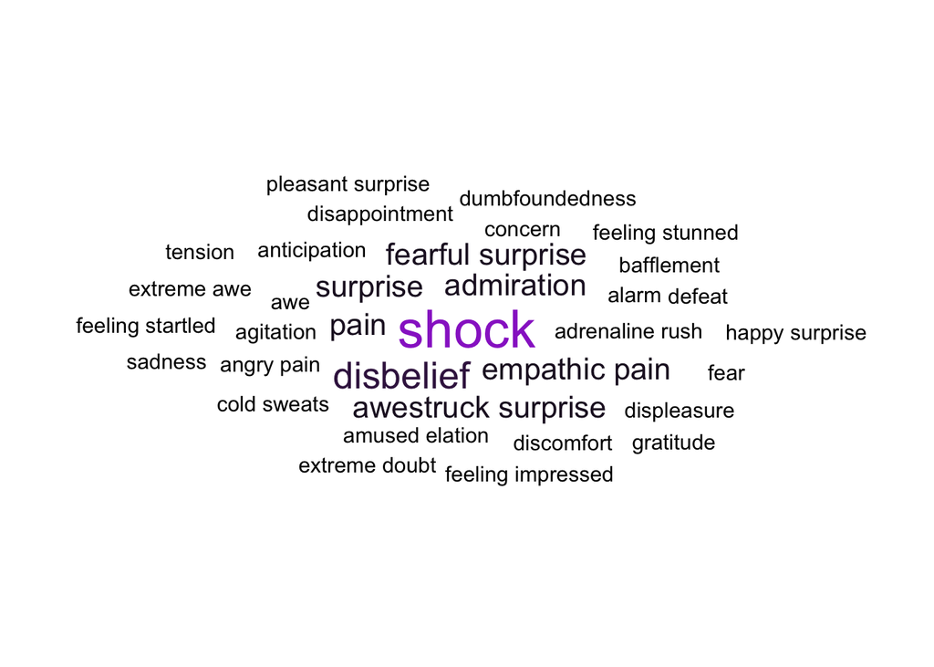

**“O” sounds**

e.g., “ooooh”, “ohh”, “uuu”

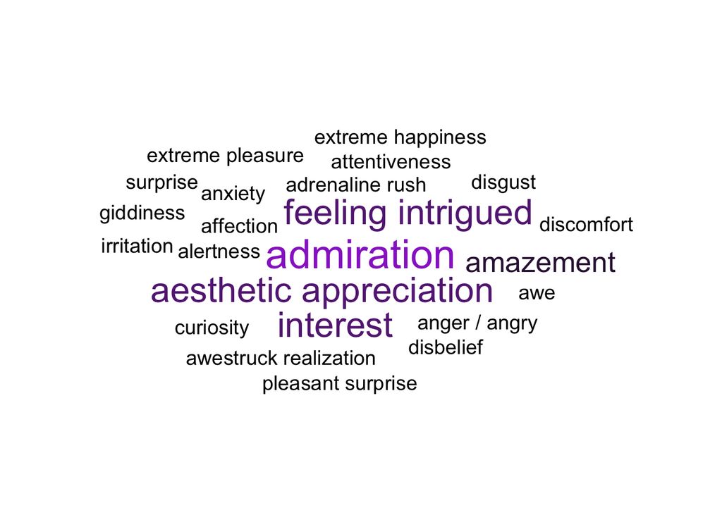

**Multi-syllable hums**

e.g., “mm-hmm”, “uhumm”, “mm mm”

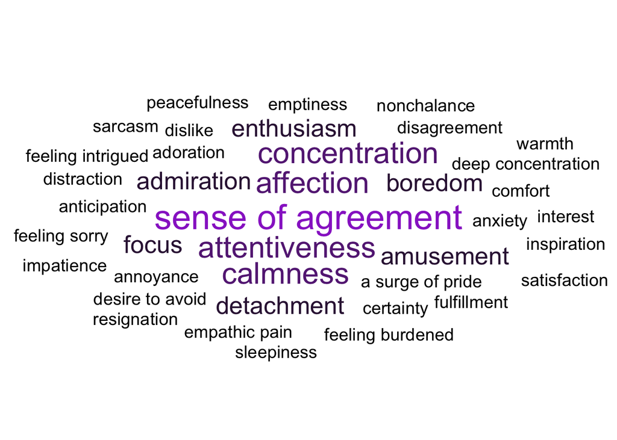

**“mmm” sounds**

e.g., “mmmm”

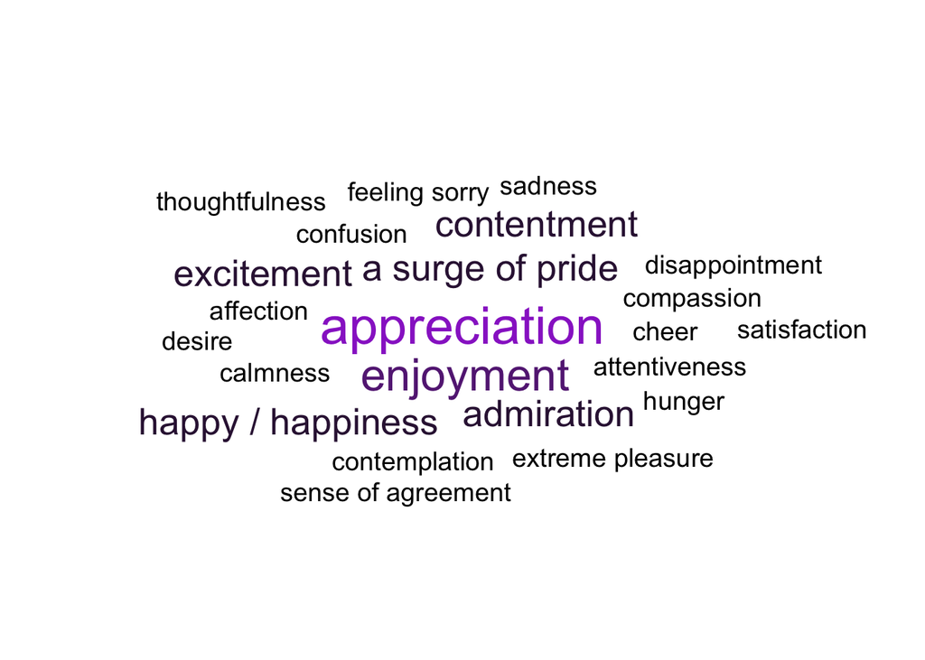

**“hmm” sounds**

e.g., “hmmm”

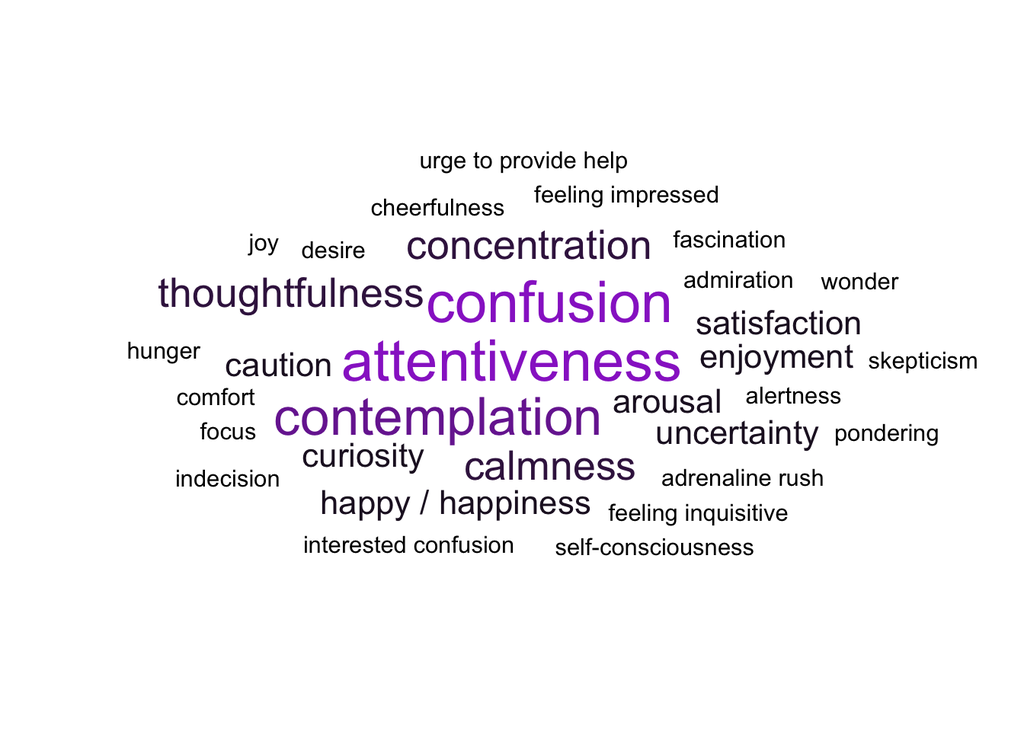

**Humming**

e.g., “humming”, “hum”

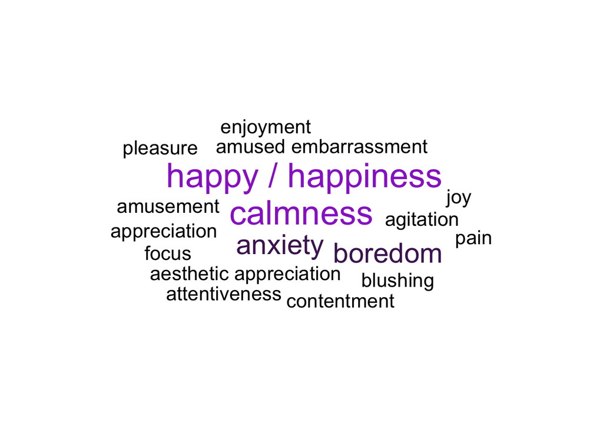

**Lip sounds (kissing/smacking lips)**

e.g., “kissing sounds”, “smacking lips”, “smack”, “muah”, “lip popping”

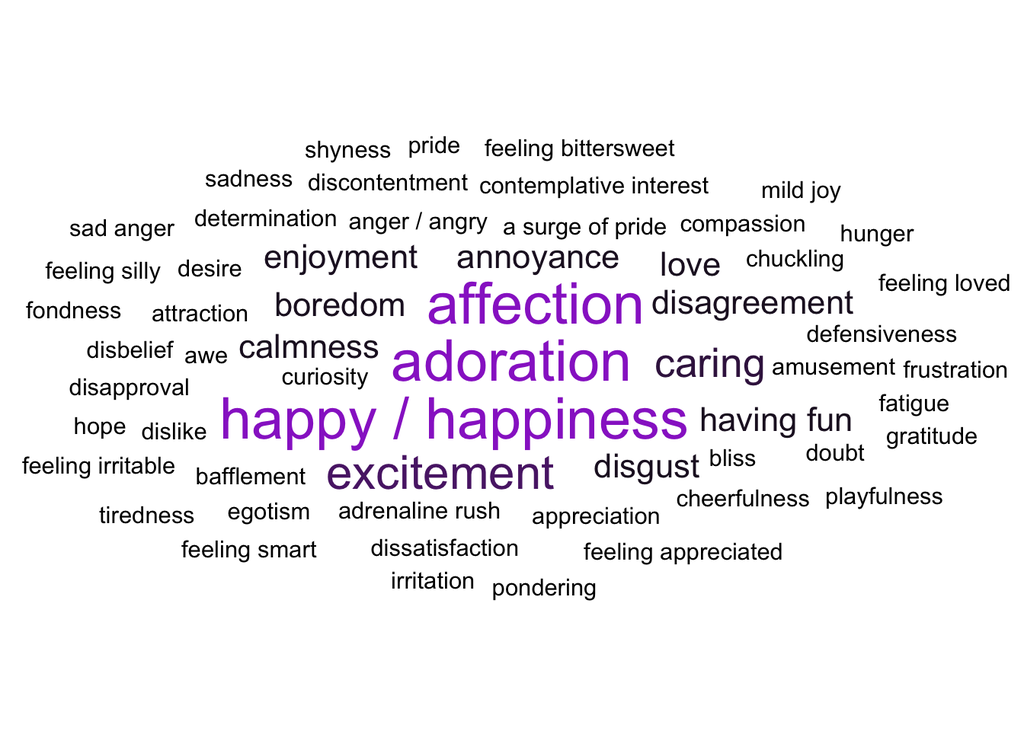

**Laughter**

e.g., “laughing”, “giggling”, “haha”, “huh, from throat, open mouth, short laugh”, “nasal breath laugh”

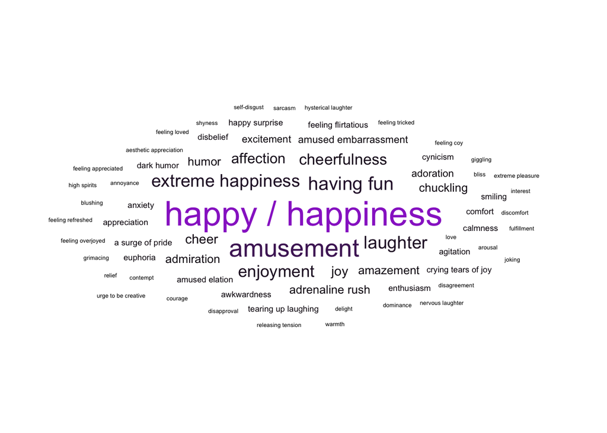

**Filler sounds (uhh/umm)**

e.g., “errr”, “uhhh”, “umms and ahhhs”, “ehm”

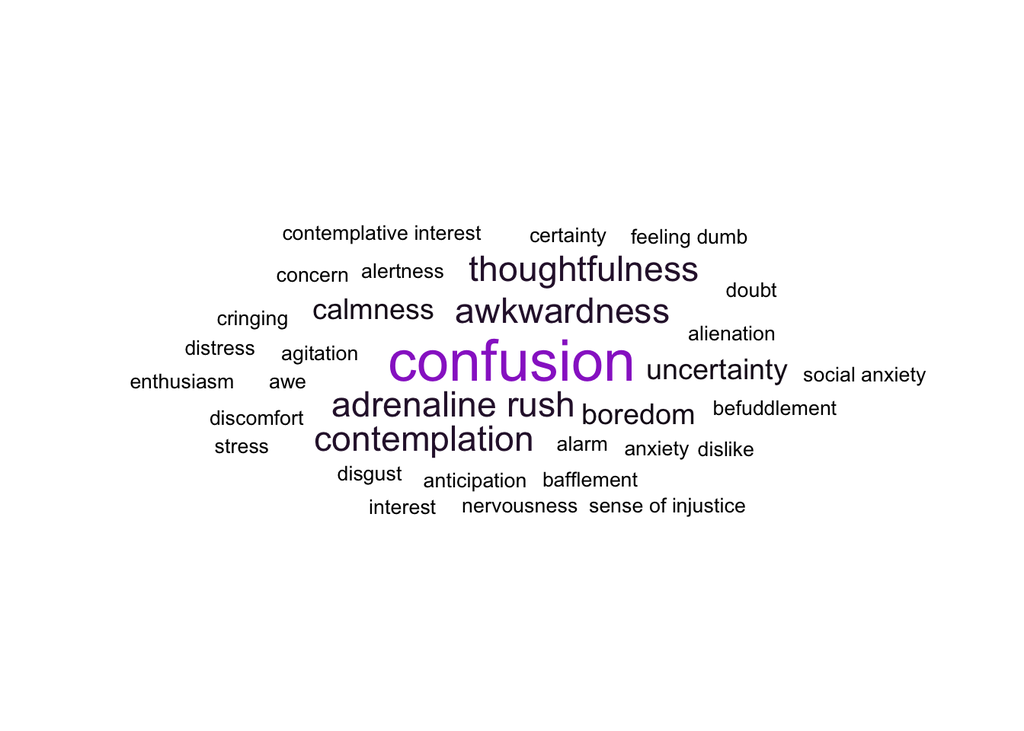

**Sighs**

e.g., “sigh”, “phew”, “puh! (relief)”, “breathing out loudly”

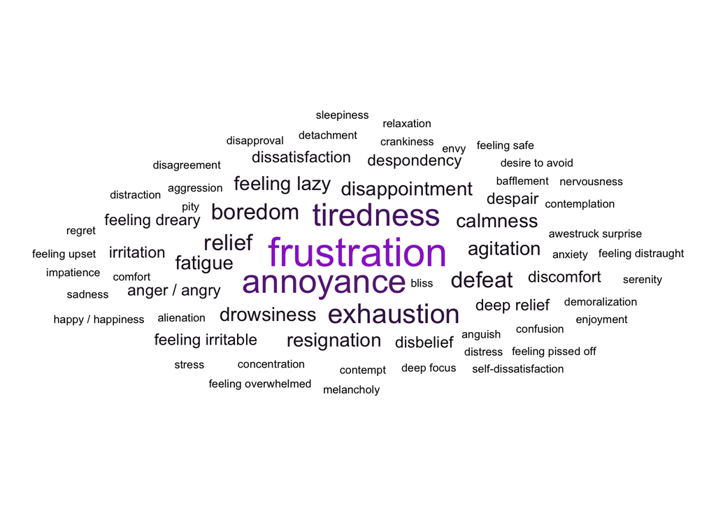

**Expressive interjections**

e.g., “ew”, “ouch”, “aha”, “aish”, “huh?”

This category is not a “real” category, but rather a catch all for semi-lexicalised non-verbal vocalisations.

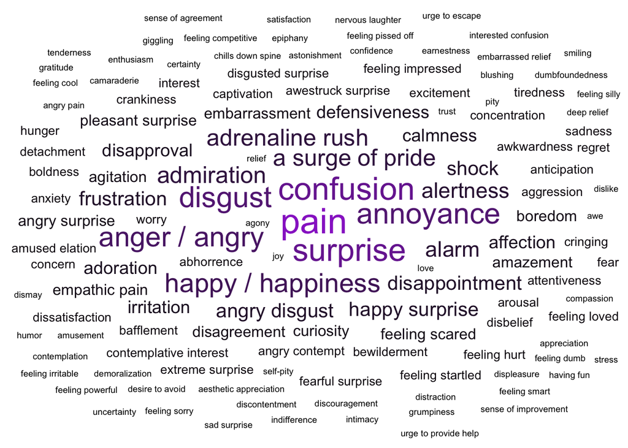

**Cheering**

e.g., “cheer”, “woohoo”, “yippee”

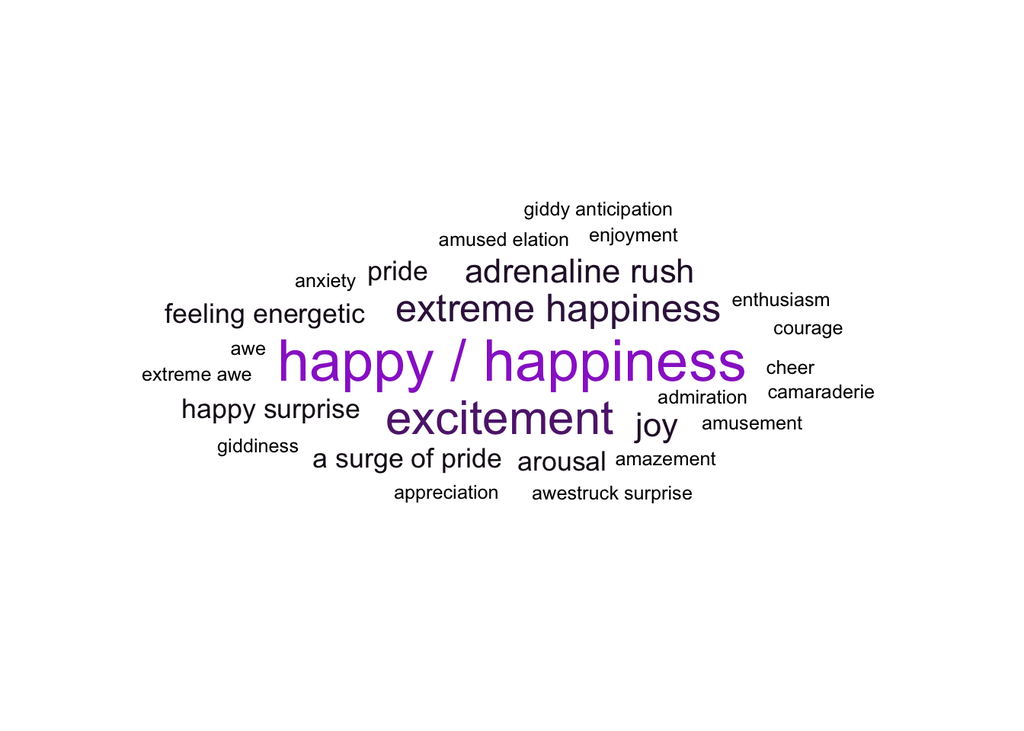

**Hissing**

e.g., “hisss”, “tssss”, “hiss when in pain”

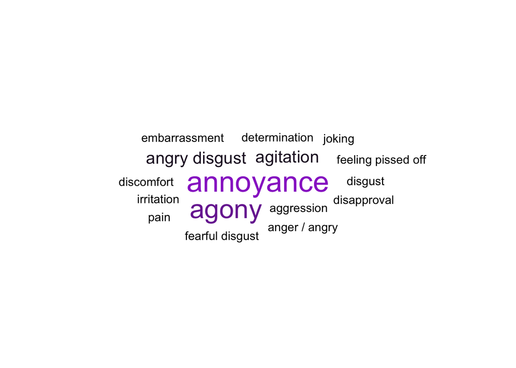

**“Pff” sounds**

e.g., “pfff”, “pffft”

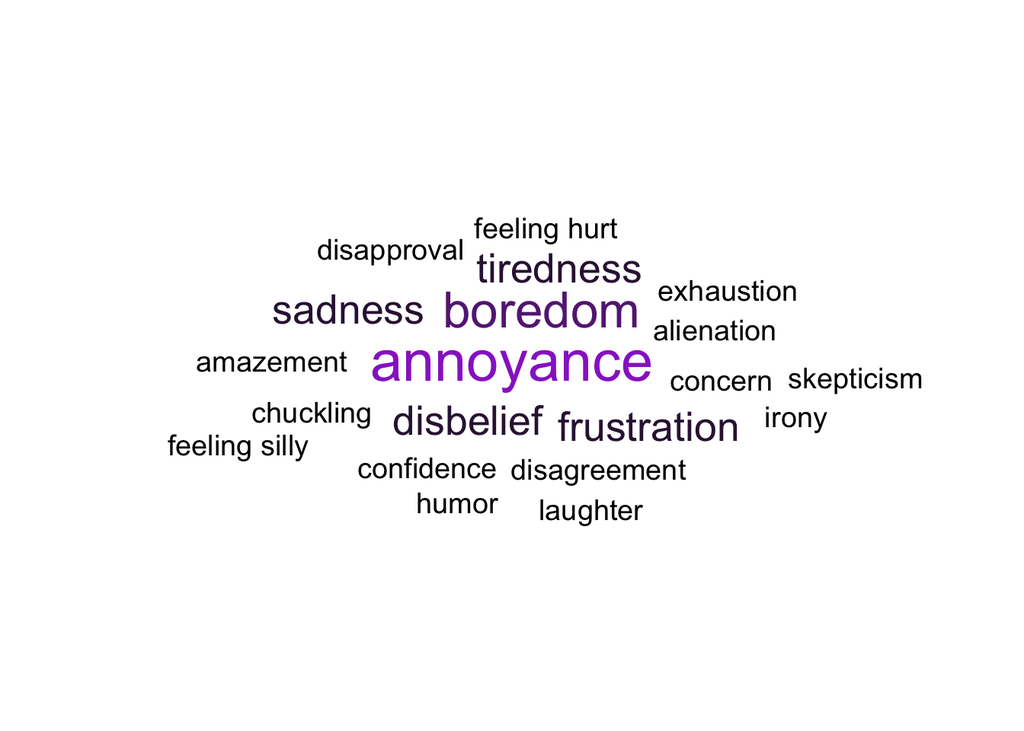

**Growls**

e.g., “growl”, “grrr”

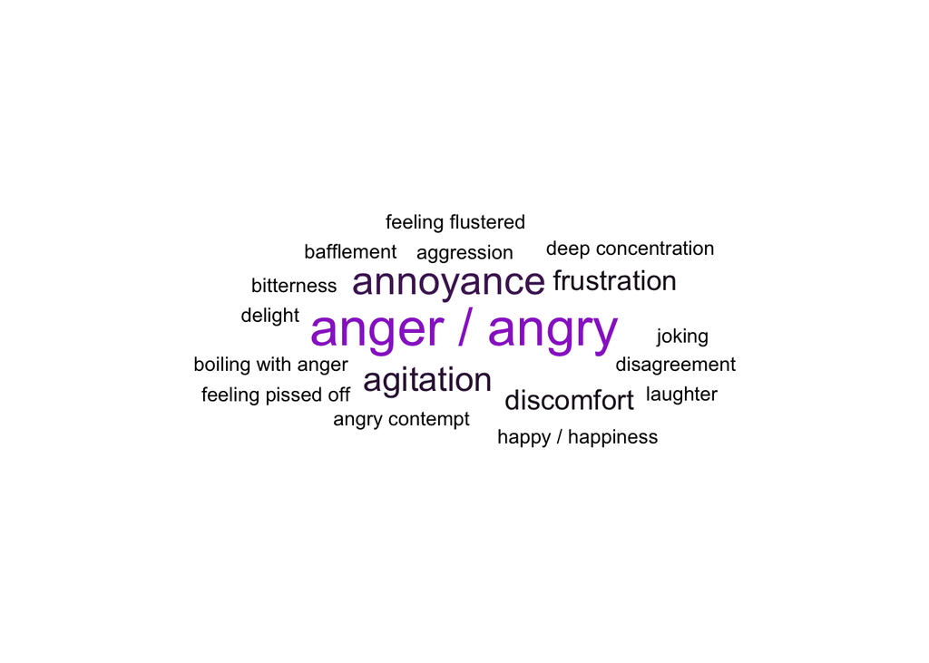

**Tutting/clicking**

e.g., “tongue clacking”, “tutting”, “tut tut”, “tsk”, “horse speed sound”, “clicking your tongue”, “ntntntntn (like not approving something)”

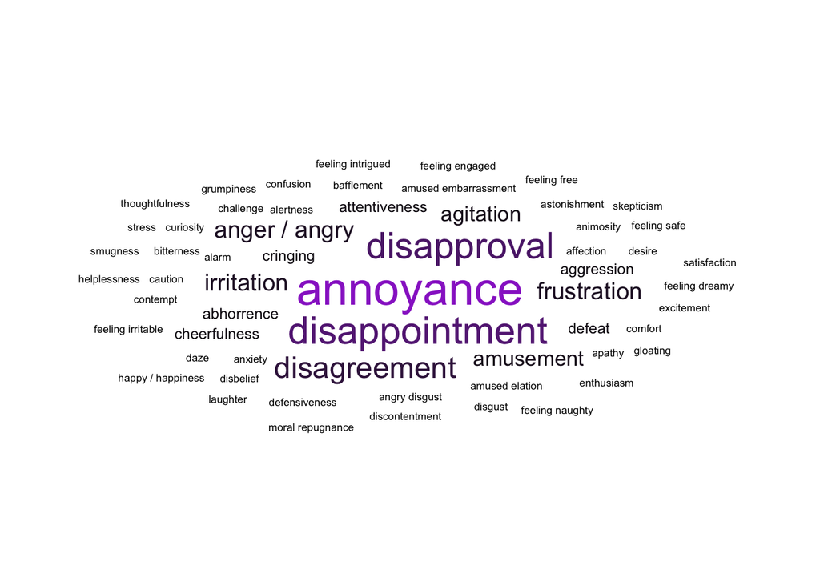

**Whistling**

e.g., “whistle”, “inhale whistle”, “fiet fiew, whistling at people in the street”

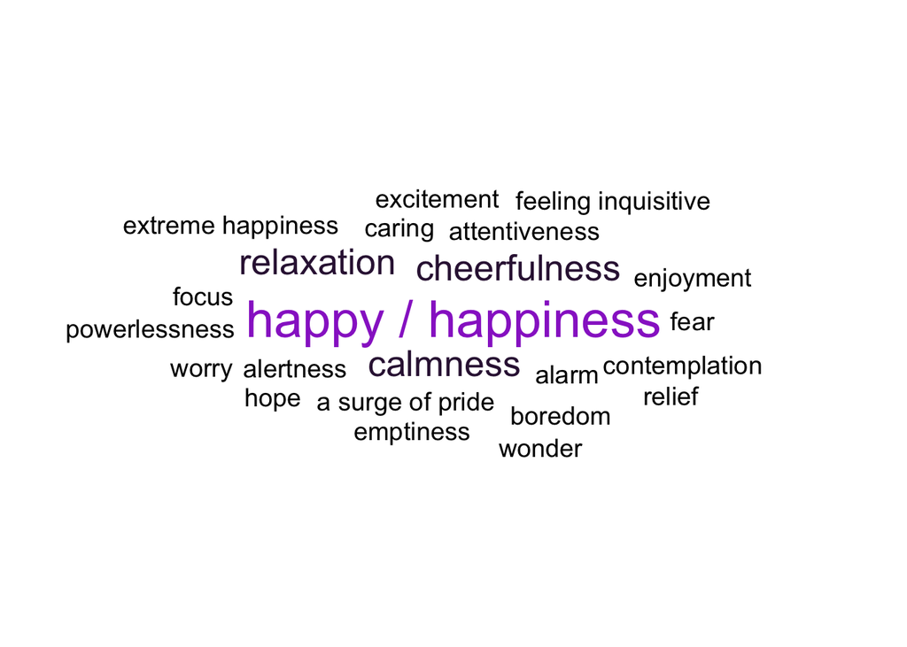

### 2.2 Some vocalisations had higher emotionality than others.

**Emotion measure**

Which emotion were you feeling? (list of ~600 emotions, participants could narrow down the list by typing)

How intense was this emotion? (0-100 slider, default set to 0)

Vocalisations like **crying/sobbing, cheering** and **screaming** were associated with more intense emotions, on average, than **filler sounds (uhh/umm), bodily functions (burps, sneezes)** and **hums (“mm hmm”, “hmm”, “humming”).**

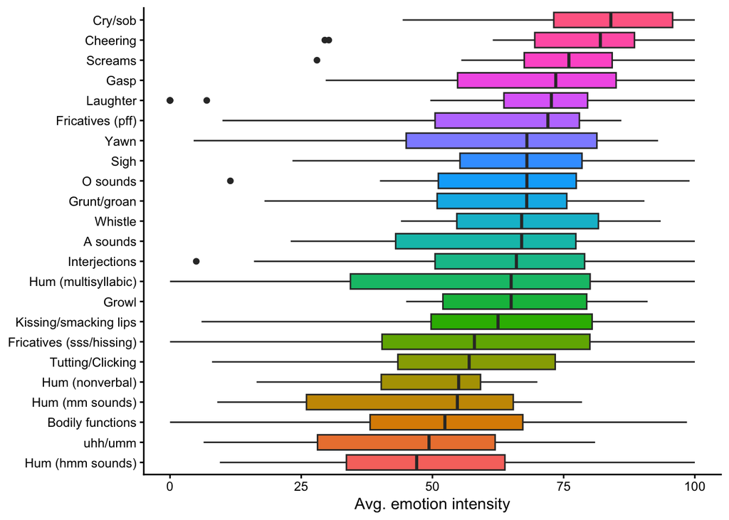

Of the 693 unique vocalisations, 36 either had no reported emotions, or were scored 0 on the emotion intensity scale.

94.81% of vocalisations were reported alongside emotions.

While the numbers of vocalisation by category are low, the plot below gives us an idea of which types of vocalisations are “less emotional”:

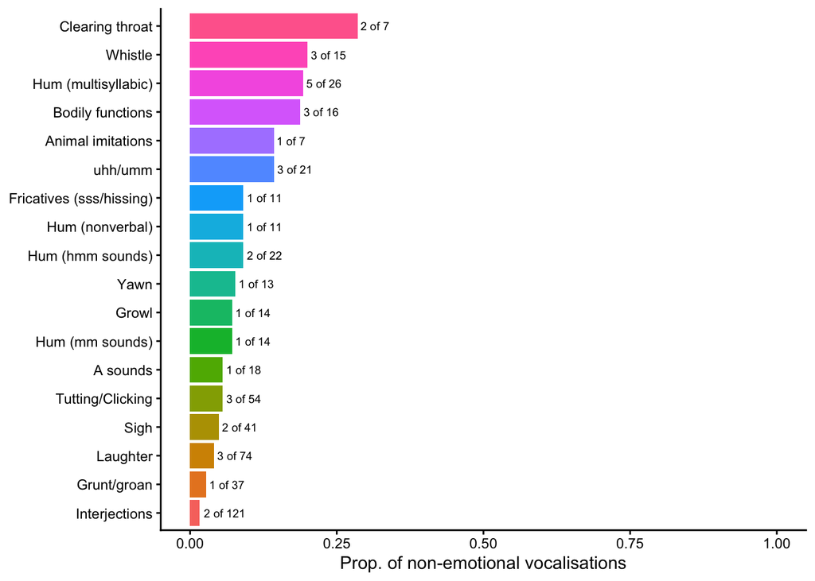

## 3 Vocal control

We asked people to tell us how much control they had over the vocalisation with the following prompt:

**Vocal control measure**

How much **control** do you think you had over this vocalization?

(0-100 Slider; from “Completely out of my control” to “Completely under my control”. Default set to midpoint.)

### 3.1 Vocalisation types differed on vocal control.

**Crying** and **screaming** were low-control vocalisations, whereas **whistling**, **smacking lips/kissing**, and **hums** were high control.

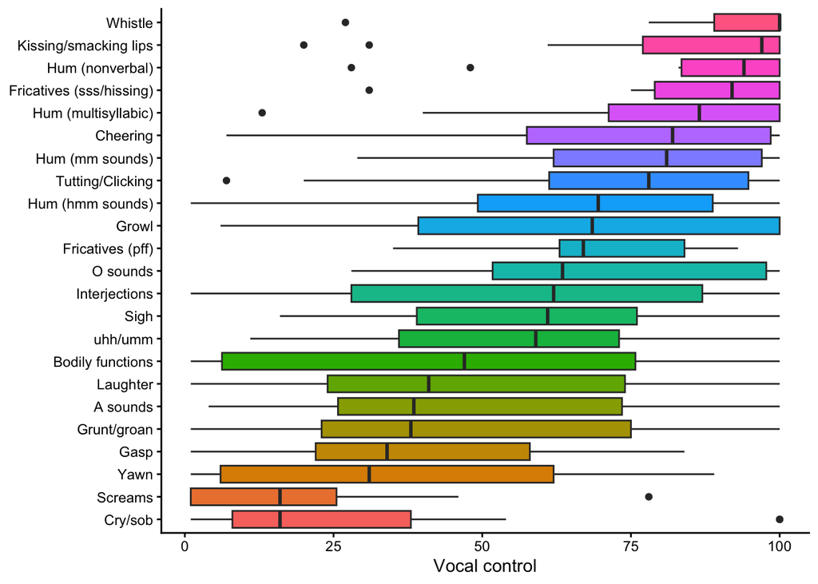

### 3.2 Intense emotions were linked to lower vocal control.

Mixed effects with random intercept per participant:

| term | estimate | std.error | statistic | p.value | signif |
| --- | --- | --- | --- | --- | --- |
| (Intercept) | 70.3862376 | 3.5857502 | 19.629432 | 0.0000000 | *** |
| emotion_intensity | -0.1695602 | 0.0537059 | -3.157201 | 0.0016653 | ** |

There’s a small but significant negative correlation (r = -0.12) between mean emotion intensity (across all reported emotions) and the amount of perceived control vocalisers had over their vocalisations.

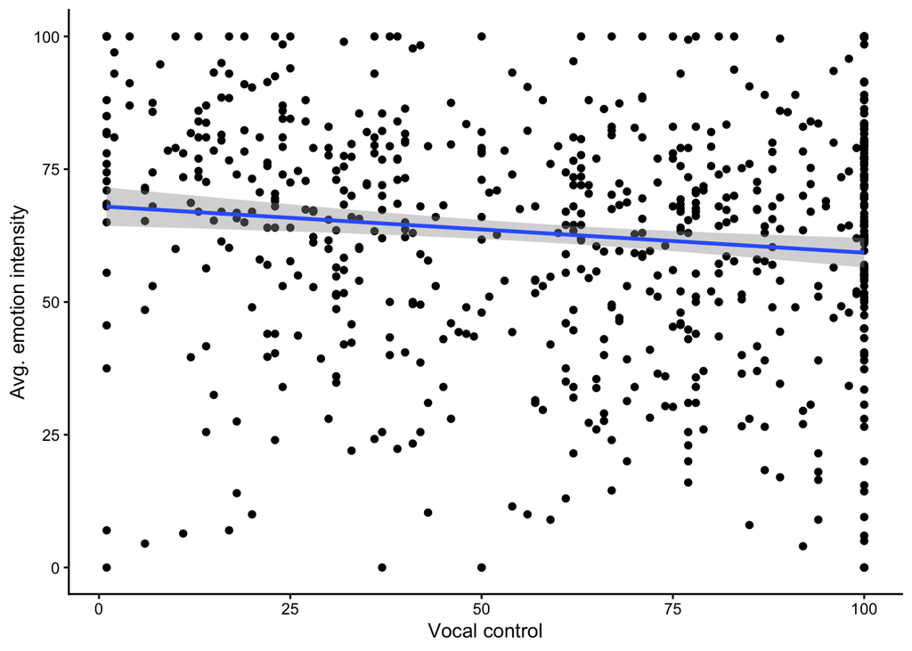

Below, I’ve mean-centered and scaled ratings on Perceived Control and Emotion Intensity. We can now see that *crying* is low control - high emotionality, while *clearing your throat* is high control - low emotionality.

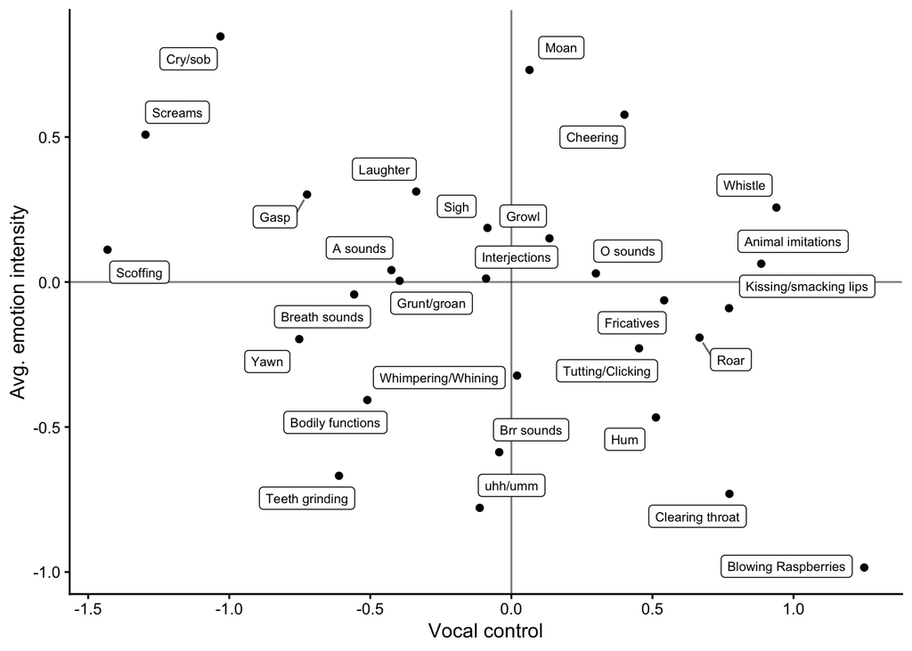

### 3.3 Vocal control was positively correlated with social dominance.

**Social dominance measure**

How **dominant/powerful** were you in this situation?  
For instance, you might feel more dominant or powerful when you are with your employees, or children.  
Or you might **not** feel dominant or powerful when you are with your boss.

(0-100 Slider; from “Not at all dominant” to “Very dominant”. Default set to midpoint.)

Mixed model (random intercept per participant):

| effect | term | estimate | std.error | statistic | df | p.value | signif |
| --- | --- | --- | --- | --- | --- | --- | --- |
| fixed | (Intercept) | 40.1847600 | 2.4739504 | 16.243155 | 556.1926 | 0 | *** |
| fixed | voc_dominance | 0.4201638 | 0.0420981 | 9.980598 | 690.9968 | 0 | *** |

Although note the collection of scores around the middle point of the scale, below. This is probably not *just* an artefact of the way the question was structured; participants didn’t gravitate towards the default answers in either the vocal control or emotion intensity prompts.

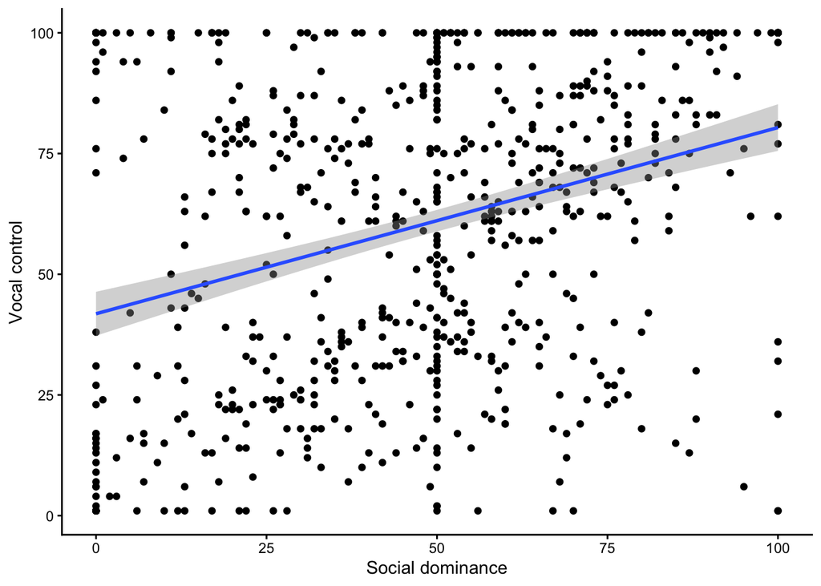

### 3.4 People controlled their vocalisations less when alone than with people they were close to.

Participants told us if they were with people they were close to, people they were not close to, or alone. The choices weren’t mutually exclusive (you could be with a group of people of different closeness levels).

I first limited the data to instances where participants reported being **only** with close others, not-close others, or alone, and compared vocal control across the three conditions.

People reported controlling their vocalisations more with close others, as compared to when alone. Other comparisons were non significant.

| social_context | emmean | SE | df | lower.CL | upper.CL |
| --- | --- | --- | --- | --- | --- |
| alone | 53.12644 | 3.395772 | 484 | 46.45416 | 59.79871 |
| close | 65.98165 | 1.751557 | 484 | 62.54006 | 69.42325 |
| not_close | 61.23288 | 3.707120 | 484 | 53.94884 | 68.51691 |

| contrast | estimate | SE | df | t.ratio | p.value |
| --- | --- | --- | --- | --- | --- |
| alone - close | -12.855215 | 3.820892 | 484 | -3.364454 | 0.0023826 |
| alone - not_close | -8.106440 | 5.027326 | 484 | -1.612475 | 0.2413013 |
| close - not_close | 4.748775 | 4.100085 | 484 | 1.158214 | 0.4788345 |

## 4 Vocalisations across contexts

### 4.1 Social dominance differed across vocalisation types.

In high-dominance contexts, people were more likely to tut or whistle, while crying and screaming were low-dominance vocalisations.

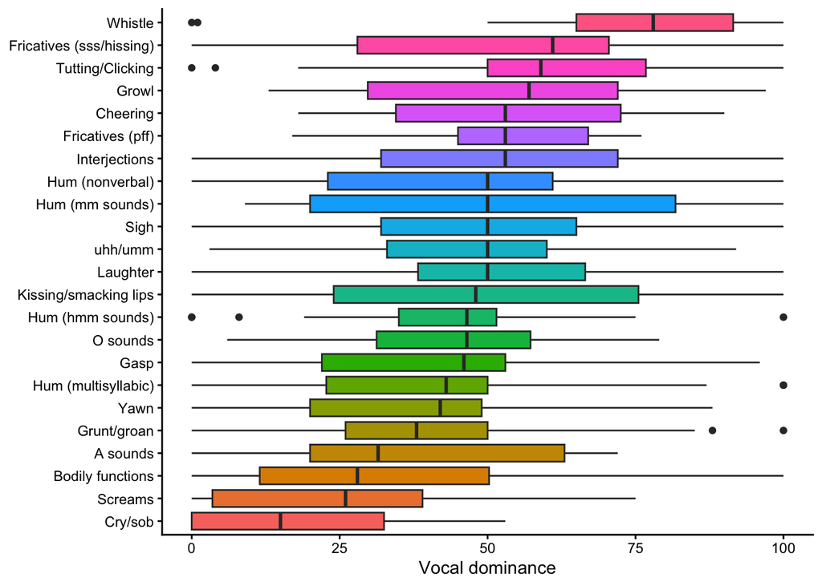

### 4.2 Vocalisation types differed based on who the vocalisers were with.

We randomly selected up to three vocalisations that people reported, and asked people who they were with when they made the sound.

People more frequently reported vocalisations made in the company of **close others**, compared to not close others or when alone.

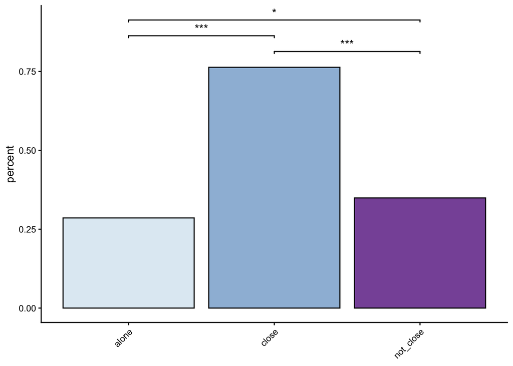

This pattern is also visible in many of the individual categories below, though lower power means only a handful are significant.

Some stand out categories where vocalisations are relatively more likely to be reported when alone are **whistling, crying, sighing.**

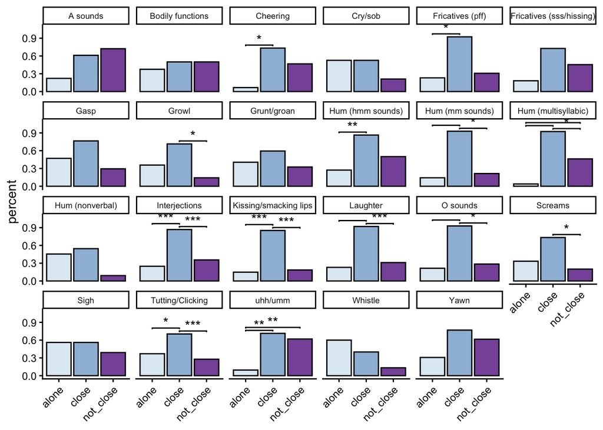